[figure not shown]

Engine Control Module (ECM) I/O Signal

ENGINE (DIAGNOSTICS)

5. Engine Control Module (ECM) I/O Signal

A: ELECTRICAL SPECIFICATION

Description

Connector

No.

nal

No.

Signal (V)

Note

Ignition SW ON

(engine OFF)

Engine ON

(idling)

Crankshaft

position sen-

sor

Signal E158 19 0 or 5 0 or 5 Waveform

Ground E158 31 0 0 —

Intake camshaft position sen-

sor (LH)

E158 21 0 or 5 0 or 5 Waveform

Intake camshaft position sen-

sor (RH)

E158 20 0 or 5 0 or 5 Waveform

Exhaust camshaft position

sensor (LH)

E158 33 0 or 5 0 or 5 Waveform

Exhaust camshaft position

sensor (RH)

E158 32 0 or 5 0 or 5 Waveform

Camshaft position sensor

ground

E158 34 0 0 —

Front oxygen

(A/F) sensor

IP+ signal E158 15 1.7 3.3 Waveform

VS+ signal E158 27 2.2 4 Waveform

COM signal E158 39 9.8 3.6 Waveform

Heater signal E159 9 12 — 15 0 or 12 — 15 Waveform

Rear oxygen

sensor

+ signal E158 16 2.0 — 3.0 2.0 — 3.0 Waveform

– signal E158 42

Heater signal E159 3 12 — 15 0 or 12 — 15 Waveform

Air flow sensor

Signal B134 16 0.3 1.2 —

Ground B134 28 0 0 —

Intake air temperature sensor

(integrated with air flow sen-

sor)

E158 5 2.7 3 After engine is warmed up.

Engine coolant temperature

sensor

E158 38 2.7 1.8 After engine is warmed up.

Engine oil temperature sensor E158 2 2.9 2.1 After engine is warmed up.

Manifold absolute pressure

sensor

E158 4 1.9 0.8 After engine is warmed up.

5

7

8

6

3

9

12

4

13

15

16

14

11

10

2526

12

21

23

24

22

1920

29

31

32

30

2728

C:

E159

7

9

10

8

5

23

1112

6

19

21

22

20

17

24

4748

18

31

33

34

32

2930

43

45

46

44

4142

3

4

12

15

16

1314

27

28

2526

39

40

3738

B:

E158

10

1112

2324

3536

4748

3

5

6

12

45

21

33

EN-09733

TO

TO

(BLACK)

(GRAY)

[figure not shown]

Engine Control Module (ECM) I/O Signal

ENGINE (DIAGNOSTICS)

Intake air temperature sensor

(integrated with manifold

absolute pressure sensor)

E158 25 3 3 After engine is warmed up.

Fuel pressure sensor E158 6 2 1 After engine is warmed up.

Knock sensor 1 E158 14 2.5 2.5 Waveform

Knock sensor 2 E158 26 2.5 2.5 Waveform

Accelerator

pedal position

sensor

Main power

supply

B134 30 5 5 —

Main signal B134 17

Fully closed:

0.4 — 1.0

Fully opened:

2.4 — 3.7

Fully closed:

0.4 — 1.0

—

Main ground B134 31 0 0 —

Sub signal B134 29

Fully closed:

0.4 — 1.0

Fully opened:

2.4 — 3.7

Fully closed:

0.4 — 1.0

—

Tumble gener-

ator valve

actuator (LH)

Position sig-

nal

E158 41 2.38 — 3.93

In closing direction:

0.43 — 1.19

In opening direction:

2.83 — 3.93

—

Motor open E159 6 10 — 13 0 or 12 — 15 Waveform

Motor closed E159 22 10 — 13 0 or 12 — 15 Waveform

Tumble gener-

ator valve

actuator (RH)

Position sig-

nal

E158 40 0.43 — 1.19

In closing direction:

2.83 — 3.93

In opening direction:

0.43 — 1.19

—

Motor open E159 14 10 — 13 0 or 12 — 15 Waveform

Motor closed E159 30 10 — 13 0 or 12 — 15 Waveform

Intake oil control solenoid (LH) E159 15 10 — 13 0 or 12 — 15 Waveform

Intake oil control solenoid

(RH)

E159 7 10 — 13 0 or 12 — 15 Waveform

Exhaust oil control solenoid

(LH)

E159 31 10 — 13 0 or 12 — 15 Waveform

Exhaust oil control solenoid

(RH)

E159 23 10 — 13 0 or 12 — 15 Waveform

Wastegate control solenoid

valve

E159 11 10 — 13 12 — 15 —

Canister purge control sole-

noid valve 1

E159 4 10 — 13 0 or 12 — 15 Waveform

Canister purge control sole-

noid valve 2

E159 12 10 — 13 0 or 12 — 15 Waveform

Ignition control

#1 E159 8 0 0 or 5 Waveform

#2 E159 16 0 0 or 5 Waveform

#3 E159 24 0 0 or 5 Waveform

#4 E159 32 0 0 or 5 Waveform

EGR control

valve

A+ E159 5 10 — 13 0 or 12 — 15 —

A- E159 21 10 — 13 0 or 12 — 15 —

B+ E159 13 10 — 13 0 or 12 — 15 —

B- E159 29 10 — 13 0 or 12 — 15 —

Description

Connector

No.

Ter mi-

nal

No.

Signal (V)

Note

Ignition SW ON

(engine OFF)

Engine ON

(idling)

[figure not shown]

Engine Control Module (ECM) I/O Signal

ENGINE (DIAGNOSTICS)

Fuel pump

control unit

Control sig-

nal

B134 40 10 — 13 0 or 12 — 15 Waveform

Diagnostic

signal

B134 44 0 12 — 15 —

High-pressure fuel pump (Hi) E158 10 2.4 — 2.5 0 or 12 — 15 Waveform

High-pressure fuel pump (Lo) E158 22 2.4 — 2.5 0 Waveform

Fuel injector

Power sup-

ply 1

B134 36 10 — 13 12 — 15 —

Power sup-

ply 2

B134 48 10 — 13 12 — 15 —

#1 (+) E158 11 0 —

Measurement is prohib-

ited while the engine is

running.

#1 (–) E158 12 0 —

#2 (+) E158 23 0 —

#2 (–) E158 24 0 —

#3 (+) E158 35 0 —

#3 (–) E158 36 0 —

#4 (+) E158 47 0 —

#4 (–) E158 48 0 —

Electronic

throttle control

Sensor

power supply

E158 18 5 5 —

Main signal E158 17

Fully closed:

Approx. 0.7

Fully open:

Approx. 3.9

Fully closed:

Approx. 0.7

After engine is warmed up.

Sub signal E158 29

Fully closed:

Approx. 4.4

Fully open:

Approx. 1.1

Fully closed:

Approx. 4.4

After engine is warmed up.

Ground E158 30 0 0 —

Motor power

supply

B134 11 10 — 13 12 — 15 —

Electronic throttle control

motor (+)

E159 2 0 0 or 12 — 15 —

Electronic throttle control

motor (–)

E159 1 0 0 or 12 — 15 —

Electronic throttle relay control B134 39 0 0 —

Starter relay control B134 14 2.9 2.9 —

Self-shutoff relay control B134 38 0 0 —

Starter cut relay control B134 13 0 0

Model with push button

start

Main fan relay control B134 37 10 — 13 0 or 12 — 15 —

Sub fan relay control B134 25 10 — 13 0 or 12 — 15 —

A/C relay control B134 1 10 — 13 0 or 12 — 15 —

Starter switch B134 45 0 0

Model with push button

start

Cranking: waveform

Starter switch 2 B134 8 0 0 Cranking: 8 — 14

Ignition switch B134 32 10 — 13 12 — 15 —

Pressure switch B134 7 10 — 13 12 — 15 —

Description

Connector

No.

Ter mi -

nal

No.

Signal (V)

Note

Ignition SW ON

(engine OFF)

Engine ON

(idling)

[figure not shown]

Engine Control Module (ECM) I/O Signal

ENGINE (DIAGNOSTICS)

Neutral position switch B134 33

ON: 0

OFF: 10 — 13

ON: 0

OFF: 12 — 15

Switch is ON when select

lever is in “P” range or “N”

range.

Cruise control

Main switch B134 20

ON: 0

OFF: 5

ON: 0

OFF: 5

—

Command

switch

B134 6

When operating

nothing: 3.5 — 4.5

When operating

RES/+: 2.5 — 3.5

When operating DIS-

TANCE: 1.5 — 2.5

When operating

SET/–: 0.5 — 1.5

When operating

CANCEL: 0 — 0.5

When operating

nothing: 3.5 — 4.5

When operating

RES/+: 2.5 — 3.5

When operating DIS-

TANCE: 1.5 — 2.5

When operating

SET/–: 0.5 — 1.5

When operating

CANCEL: 0 — 0.5

—

Clutch switch B134 34

When clutch pedal is

depressed: 0

When clutch pedal is

released: 10 — 13

When clutch pedal is

depressed: 0

When clutch pedal is

released: 12 — 15

MT model

Brake switch 1

(brake switch)

B134 43

When brake pedal is

depressed: 0

When brake pedal is

released: 10 — 13

When brake pedal is

depressed: 0

When brake pedal is

released: 10 — 13

—

Brake switch 2

(stop light switch)

E158 8

When brake pedal is

depressed: 10 — 13

When brake pedal is

released: 0

When brake pedal is

depressed: 10 — 13

When brake pedal is

released: 0

—

Oil level switch E158 44 0 0 Oil level LOW: 10 — 14

Accessory cut request B134 2 10 — 13 12 — 15

Model with push button

start

Cranking: 0

Engine speed output B134 4 10 — 13 0 or 12 — 15

Model with push button

start

Waveform

Generator control B134 26 1.8 1.8 After engine is warmed up.

CAN commu-

nication

(Hi) B134 10 — — —

(Lo) B134 9 — — —

LIN communication E158 3 — — —

Immobilizer communication E158 43 — — —

Delivery mode switch E158 45 10 — 13 12 — 15 —

Control module power supply

B134 12 10 — 13 12 — 15 —

B134 24 10 — 13 12 — 15 —

Back-up power supply B134 23 10 — 13 12 — 15 —

Sensor power supply

B134 18 5 5 —

E159 19 5 5 —

ELCM

Switching

valve

B134 27 10 — 13 12 — 14 Operating: 0

Pressure

sensor

B134 15 1 — 4 1 — 4

When ignition switch is

turned to ON: atmo-

spheric pressure

Vacuum

pump

B134 3 10 — 13 12 — 14 Operating: 0

Description

Connector

No.

Ter mi -

nal

No.

Signal (V)

Note

Ignition SW ON

(engine OFF)

Engine ON

(idling)

[figure not shown]

Engine Control Module (ECM) I/O Signal

ENGINE (DIAGNOSTICS)

Brake booster pressure sen-

sor

E158 13 0.8 — 1.2 1.0 — 1.6

After engine is warmed up.

When brake pedal is

released.

Brake vacuum pump E158 1 0 0 After engine is warmed up.

Brake vacuum pump relay E158 37 10 — 13 12 — 15 After engine is warmed up.

Sensor ground

B134 19 0 0 —

E159 27 0 0 —

Ground

Engine 1 B134 35 0 0 —

Engine 2 B134 47 0 0 —

Engine 3 E159 10 0 0 —

Engine 4 E159 18 0 0 —

Engine 5 E159 26 0 0 —

Engine 6 E159 17 0 0 —

Engine 7 E159 25 0 0 —

Description

Connector

No.

Ter mi -

nal

No.

Signal (V)

Note

Ignition SW ON

(engine OFF)

Engine ON

(idling)

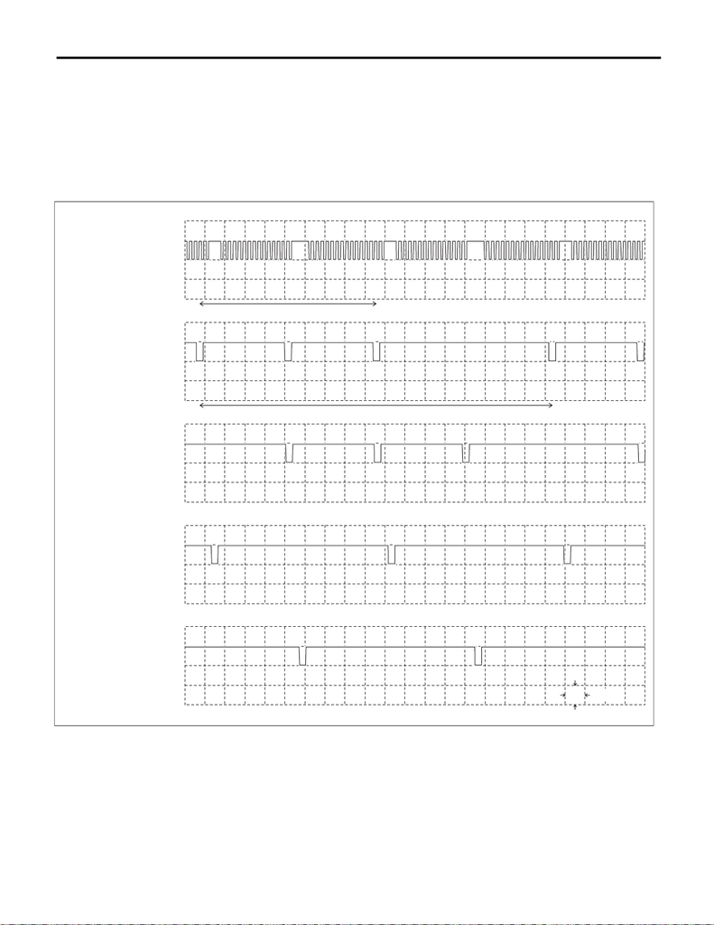

EN(w/o STI)(diag)-25

Engine Control Module (ECM) I/O Signal

ENGINE (DIAGNOSTICS)

Input/output name:

• Crankshaft position sensor

• Intake camshaft position sensor RH

• Intake camshaft position sensor LH

• Exhaust camshaft position sensor RH

• Exhaust camshaft position sensor LH

Measuring condition:

• After warming-up

• At idling

0

0

5V

10ms

0

0

0

EN-10820

EXHAUST CAMSHAFT

POSITION SENSOR RH

EXHAUST CAMSHAFT

POSITION SENSOR LH

CRANKSHAFT

POSITION SENSOR

INTAKE CAMSHAFT

POSITION SENSOR RH

INTAKE CAMSHAFT

POSITION SENSOR LH

ONE CAMSHAFT ROTATION

ONE CRANKSHAFT ROTATION

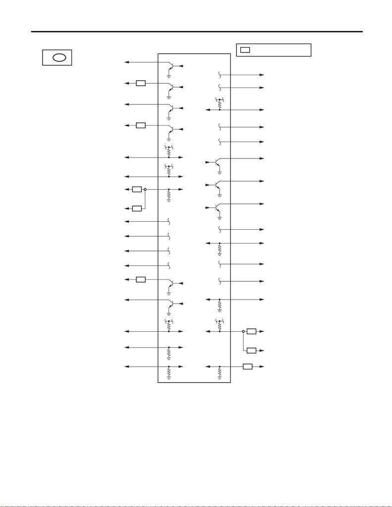

EN(w/o STI)(diag)-26

Engine Control Module (ECM) I/O Signal

ENGINE (DIAGNOSTICS)

A34

MT

CVT

MT

A13

WP

B134A:

EN-10821

A12

A11

A10

A9

A1

A23

A25

A24

A19

A20

A28

A26

A6

A7

A8

A14

A16

A17

A29

A30

A31

A32

WP

A2

WP

A4

WP

A3

A15

A18

A27

A33

CVT

MT

INHIBITOR SWITCH

NEUTRAL POSITION SWITCH

LEAK CHECK VALVE ASSY

POWER LINES

LEAK CHECK VALVE ASSY

LEAK CHECK VALVE ASSY

KEYLESS ACCESS CM

KEYLESS ACCESS CM

: WITH PUSH BUTTON START

F/B FUSE No. 12

ACCELERATOR PEDAL POSITION SENSOR

ACCELERATOR PEDAL POSITION SENSOR

ACCELERATOR PEDAL POSITION SENSOR

ACCELERATOR PEDAL POSITION SENSOR

MASS AIR FLOW &

INTAKE AIR TEMPERATURE SENSOR

STARTER RELAY

INHIBITOR SWITCH

PRESSURE SWITCH

CRUISE CONTROL SWITCH

GENERATOR

MASS AIR FLOW &

INTAKE AIR TEMPERATURE SENSOR

CRUISE CONTROL SWITCH

GROUNDS

MAIN RELAY

SUB FAN RELAY

M/B FUSE No. 13

A/C RELAY

SEVERAL MODULES

(CAN COMMUNICATION)

SEVERAL MODULES

(CAN COMMUNICATION)

ELECTRONIC THROTTLE CONTROL RELAY

MAIN RELAY

STARTER CUT RELAY

STARTER RELAY

CLUTCH SWITCH

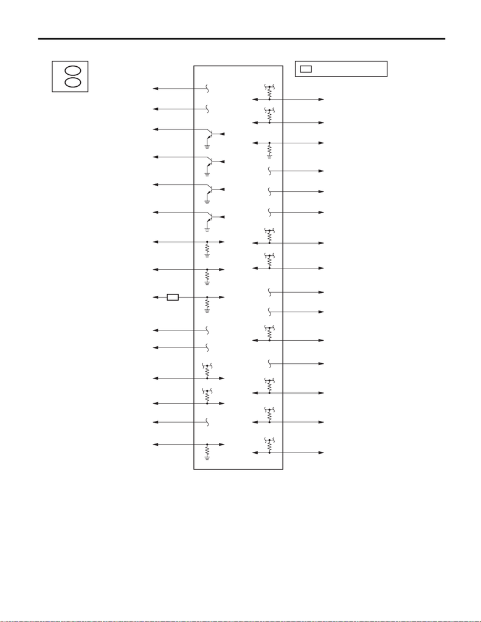

EN(w/o STI)(diag)-27

Engine Control Module (ECM) I/O Signal

ENGINE (DIAGNOSTICS)

A45

WP

EN-10822

A39

A38

A37

A40

A47

B8

B11

A43

B10

B134A:

E158B:

A44

A48

B4

B2

B14

B15

B17

B18

B19

B12

B20

B21

WP

B13

B1

B3

A35

A36

B5

B6

B16

REAR OXYGEN SENSOR

FUEL PRESSURE SENSOR

MASS AIR FLOW &

INTAKE AIR TEMPERATURE SENSOR

FUEL INJECTOR RELAY

ENGINE GROUND

BATTERY SENSOR

BRAKE VACUUM PUMP RELAY

BRAKE BOOSTER PRESSURE SENSOR

: WITH PUSH BUTTON START

INTAKE CAMSHAFT POSITION SENSOR LH

INTAKE CAMSHAFT POSITION SENSOR RH

FUEL INJECTOR No. 1

CRANKSHAFT POSITION SENSOR

ELECTRONIC THROTTLE CONTROL

ELECTRONIC THROTTLE CONTROL

FRONT OXYGEN (A/F) SENSOR

KNOCK SENSOR RH

ENGINE OIL TEMPERATURE SENSOR

MANIFOLD ABSOLUTE PRESSURE &

INTAKE AIR TEMPERATURE SENSOR

FUEL INJECTOR RELAY

FUEL PUMP CU

HIGH-PRESSURE FUEL PUMP

BRAKE SWITCH

FUEL INJECTOR No. 1

STOP LIGHT SWITCH

ENGINE GROUND

FUEL PUMP CU

MAIN FAN RELAY

RELAY CONTROLS

ELECTRONIC THROTTLE CONTROL RELAY

KEYLESS ACCESS CM

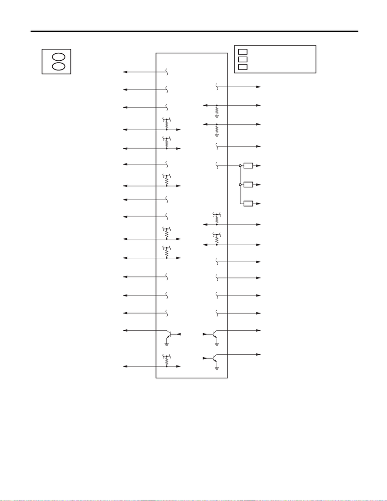

EN(w/o STI)(diag)-28

Engine Control Module (ECM) I/O Signal

ENGINE (DIAGNOSTICS)

ID

B43

OP

ND

B39

EN-10823

B40

E158B:

E159C:

B25

B45

B23

B24

B26

B29

B27

B32

B30

B31

B33

B34

B35

B36

B41

B47

B48

C1

C3

C2

C4

B22

B37

B44

OP

ND

B42

ID

B38

ENGINE COOLANT TEMPERATURE SENSOR

: WITH ID CODE BOX

REAR OXYGEN SENSOR

: WITHOUT ID CODE BOX

: WITHOUT PUSH BUTTON START

OIL LEVEL SWITCH

BRAKE VACUUM PUMP RELAY

HIGH-PRESSURE

FUEL PUMP

PURGE CONTROL SOLENOID VALVE 1

ELECTRONIC THROTTLE CONTROL

REAR OXYGEN SENSOR

ELECTRONIC THROTTLE CONTROL

FUEL INJECTOR No. 4

FUEL INJECTOR No. 4

TUMBLE GENERATOR VALVE ACTUATOR LH

FUEL INJECTOR No. 3

FUEL INJECTOR No. 3

EACH CAMSHAFT POSITION SENSOR

(GROUND)

EXHAUST CAMSHAFT POSITION SENSOR LH

CRANKSHAFT POSITION SENSOR

ELECTRONIC THROTTLE CONTROL

EXHAUST CAMSHAFT POSITION SENSOR RH

FRONT OXYGEN (A/F) SENSOR

ELECTRONIC THROTTLE CONTROL

KNOCK SENSOR LH

FUEL INJECTOR No. 2

FUEL INJECTOR No. 2

DELIVERY MODE FUSE

MANIFOLD ABSOLUTE PRESSURE &

INTAKE AIR TEMPERATURE SENSOR

TUMBLE GENERATOR VALVE ACTUATOR RH

FRONT OXYGEN (A/F) SENSOR

BODY INTEGRATED UNIT

KEYLESS ACCESS CM

ID CODE BOX

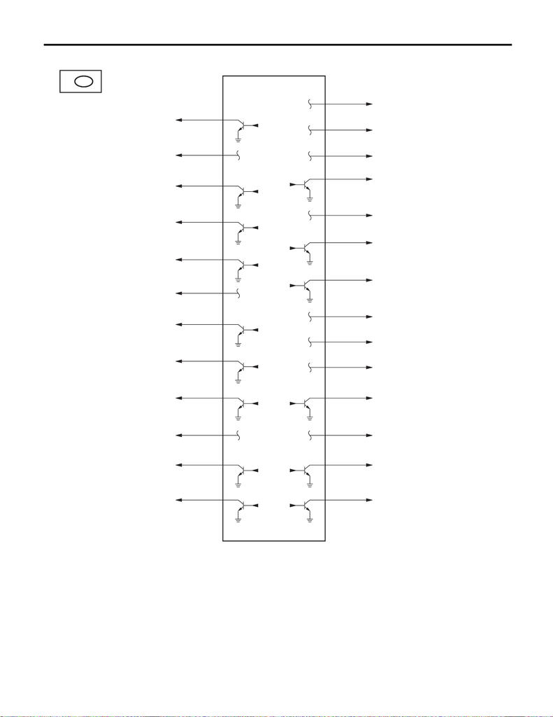

EN(w/o STI)(diag)-29

Engine Control Module (ECM) I/O Signal

ENGINE (DIAGNOSTICS)

EN-10230

E159C:

C10

C19

C22

C21

C23

C24

C7

C8

C9

C14

C15

C16

C25

C26

C27

C30

C29

C31

C32

C11

C12

C13

C6

C5

C17

C18

ENGINE GROUND

ENGINE GROUND

EGR CONTROL VALVE

TUMBLE GENERATOR

VALVE ACTUATOR LH

EGR CONTROL VALVE

PURGE CONTROL

SOLENOID VALVE 2

WASTEGATE CONTROL

SOLENOID VALVE

IGNITION COIL No. 4

EXHAUST OIL CONTROL

SOLENOID LH

EGR CONTROL VALVE

TUMBLE GENERATOR

VALVE ACTUATOR RH

GROUNDS

ENGINE GROUND

ENGINE GROUND

IGNITION COIL No. 2

INTAKE OIL CONTROL

SOLENOID LH

TUMBLE GENERATOR

VALVE ACTUATOR RH

FRONT OXYGEN (A/F) SENSOR

IGNITION COIL No. 1

INTAKE OIL CONTROL

SOLENOID RH

IGNITION COIL No. 3

EXHAUST OIL CONTROL

SOLENOID RH

EGR CONTROL VALVE

TUMBLE GENERATOR

VALVE ACTUATOR LH

POWER LINES

ENGINE GROUND